# ANOVA mista no R (analisando dados em painel)

A ANOVA mista também pode ser chamada de ANOVA com medidas repetidas.

# 1 O que vamos executar?

- Verificar os pressupostos (normalidade, homogeneidade de variâncias, esfericidade e ausência de *outliers*);
- Fazer a ANOVA mista;
- Analisar a diferença entre os grupos pelas “médias marginais estimadas” com correção de *Bonferroni*;
- Pedir o gráfico da interação e as estatísticas descritivas;
- Descrever os resultados.

# 2 Situação problema

O `Banco de Dados 7.4.csv` contém informações de 48 indivíduos (21 do gênero feminino e 27 do gênero masculino) submetidos a uma dieta e acompanhados ao longo do tempo. Foram aferidas 5 medidas de triglicérides e 5 medidas de peso. Uma antes do início da dieta e então uma acada semana. Verifique se há efeito da dieta sobre o triglicérides e se esse efeito depende do gênero. Descreva os resultados de forma apropriada.

# 3 Efetuando a Análise

É necessário seguir alguns passos importantes.

## 3.1 Passo 1: Carregar os pacotes de dados

```r
if(!require(dplyr)) install.packages("dplyr")
library(dplyr)
if(!require(ez)) install.packages("ez")
library(ez)
if(!require(rstatix)) install.packages("rstatix")
library(rstatix)
if(!require(reshape)) install.packages("reshape")
library(reshape)
if(!require(car)) install.packages("car")
library(car)
if(!require(emmeans)) install.packages("emmeans")
library(emmeans)
if(!require(ggplot2)) install.packages("ggplot2")
library(ggplot2)
if(!require(data.table)) install.packages("data.table")
library(data.table)
library(rmarkdown)
library(DT)
```

## 3.2 Passo 2: Carregar o banco de dados

Detalhe importante: selecionar o diretório de trabalho via *Session/Set Working Directory/Choose Directory*.

```r
Sys.setenv(TMPDIR = "C:/R-Temp") # Esse diretório temporário foi retificado por ser mais curto
dados <- read.csv2('Banco de Dados 7.4.csv', stringsAsFactors = T,
                   fileEncoding = "latin1")
glimpse(dados)
```

```
## Rows: 48
## Columns: 12
## $ ID     <int> 1, 2, 3, 4, 5, 6, 7, 8, 9, 10, 11, 12, 13, 14, 15, 16, 17, 18, ~
## $ Gênero <fct> Masculino, Masculino, Masculino, Feminino, Masculino, Feminino,~
## $ TG.1   <int> 180, 139, 152, 112, 156, 167, 138, 160, 107, 156, 94, 107, 145,~
## $ TG.2   <int> 148, 94, 185, 145, 104, 138, 132, 128, 120, 103, 144, 93, 107, ~
## $ TG.3   <int> 106, 119, 86, 136, 157, 88, 146, 150, 129, 126, 114, 156, 129, ~
## $ TG.4   <int> 113, 75, 149, 149, 79, 107, 143, 118, 195, 135, 114, 148, 86, 1~
## $ TG.5   <int> 100, 92, 118, 82, 97, 171, 132, 123, 174, 92, 121, 150, 159, 10~
## $ Peso.1 <int> 198, 237, 233, 179, 219, 169, 222, 167, 199, 233, 179, 158, 157~
## $ Peso.2 <int> 196, 233, 231, 181, 217, 166, 219, 167, 200, 229, 181, 153, 151~
## $ Peso.3 <int> 193, 232, 229, 177, 215, 165, 215, 166, 196, 229, 176, 155, 150~
## $ Peso.4 <int> 188, 228, 228, 174, 213, 162, 215, 162, 196, 229, 173, 155, 145~
## $ Peso.5 <int> 192, 225, 226, 172, 214, 161, 210, 161, 193, 226, 173, 154, 143~
```

```r
tabela1_dados <- datatable(dados, options = list(pageLength = 10))
tabela1_dados
```

|  | ID | Gênero | TG.1 | TG.2 | TG.3 | TG.4 | TG.5 | Peso.1 | Peso.2 | Peso.3 | Peso.4 | Peso.5 |
| --- | --- | --- | --- | --- | --- | --- | --- | --- | --- | --- | --- | --- |
| 1 | 1 | Masculino | 180 | 148 | 106 | 113 | 100 | 198 | 196 | 193 | 188 | 192 |
| 2 | 2 | Masculino | 139 | 94 | 119 | 75 | 92 | 237 | 233 | 232 | 228 | 225 |
| 3 | 3 | Masculino | 152 | 185 | 86 | 149 | 118 | 233 | 231 | 229 | 228 | 226 |
| 4 | 4 | Feminino | 112 | 145 | 136 | 149 | 82 | 179 | 181 | 177 | 174 | 172 |
| 5 | 5 | Masculino | 156 | 104 | 157 | 79 | 97 | 219 | 217 | 215 | 213 | 214 |
| 6 | 6 | Feminino | 167 | 138 | 88 | 107 | 171 | 169 | 166 | 165 | 162 | 161 |
| 7 | 7 | Masculino | 138 | 132 | 146 | 143 | 132 | 222 | 219 | 215 | 215 | 210 |
| 8 | 8 | Feminino | 160 | 128 | 150 | 118 | 123 | 167 | 167 | 166 | 162 | 161 |
| 9 | 9 | Masculino | 107 | 120 | 129 | 195 | 174 | 199 | 200 | 196 | 196 | 193 |
| 10 | 10 | Masculino | 156 | 103 | 126 | 135 | 92 | 233 | 229 | 229 | 229 | 226 |

[output cut: 38 more lines]

Lembrar sempre que quando usamos `glimpse` é para verificar a categoria da variável dentro de seus respectivos grupos. Por exemplo, as variáveis `ID`, `TG.1`a `TG.5`, e `Peso.1` a `Peso.5` estão representadas por `<int>` que significa que os dados são apresentados em números inteiros; enquanto que a variável `Gênero` está representada por `<fct>` que significa fator (no caso, `Masculino` ou `Feminino`).

## 3.3 Passo 3: Alterar o formato do banco de dados de “wide” para “long”

Quando trabalhamos com banco de dados no modelo de painel, precisamos reestruturar a fim de evidenciar o recorte para cada elemento da análise, como nesse caso, as pessoas categorizadas pela variável `ID` qualificadas pelos triglicérides e pelo peso, assim como pelo gênero.

### 3.3.1 Reestruturando o banco de dados

```r
dadosl <- reshape(dados, direction="long",
                  idvar = "ID",
                  varying = list(c("TG.1","TG.2","TG.3","TG.4","TG.5"),
                                 c("Peso.1","Peso.2","Peso.3","Peso.4","Peso.5")),
                  v.names = c("TG", "Peso"),
                  timevar = "Tempo")
```

### 3.3.2 Ordenando as colunas pelo sujeito experimental

```r
dadosl <- sort_df(dadosl, vars = "ID")
glimpse(dadosl)
```

```
## Rows: 240
## Columns: 5
## $ ID     <int> 1, 1, 1, 1, 1, 2, 2, 2, 2, 2, 3, 3, 3, 3, 3, 4, 4, 4, 4, 4, 5, ~
## $ Gênero <fct> Masculino, Masculino, Masculino, Masculino, Masculino, Masculin~
## $ Tempo  <int> 1, 2, 3, 4, 5, 1, 2, 3, 4, 5, 1, 2, 3, 4, 5, 1, 2, 3, 4, 5, 1, ~
## $ TG     <int> 180, 148, 106, 113, 100, 139, 94, 119, 75, 92, 152, 185, 86, 14~
## $ Peso   <int> 198, 196, 193, 188, 192, 237, 233, 232, 228, 225, 233, 231, 229~
```

### 3.3.3 Transformando as variáveis `ID` e `Tempo` em fator:

```r
dadosl$ID <- factor(dadosl$ID)
dadosl$Tempo <- factor(dadosl$Tempo)

tabela2_dadosl <- datatable(dadosl, options = list(pageLength = 10))
tabela2_dadosl
```

|  | ID | Gênero | Tempo | TG | Peso |
| --- | --- | --- | --- | --- | --- |
| 1.1 | 1 | Masculino | 1 | 180 | 198 |
| 1.2 | 1 | Masculino | 2 | 148 | 196 |
| 1.3 | 1 | Masculino | 3 | 106 | 193 |
| 1.4 | 1 | Masculino | 4 | 113 | 188 |
| 1.5 | 1 | Masculino | 5 | 100 | 192 |
| 2.1 | 2 | Masculino | 1 | 139 | 237 |
| 2.2 | 2 | Masculino | 2 | 94 | 233 |
| 2.3 | 2 | Masculino | 3 | 119 | 232 |
| 2.4 | 2 | Masculino | 4 | 75 | 228 |
| 2.5 | 2 | Masculino | 5 | 92 | 225 |

[output cut: 230 more lines]

## 3.4 Passo 4: Checar os pressupostos de normalidade e ausência de *outliers* (pacote: `rstatix`)

### 3.4.1 Verificando a presença de *outliers* por grupo:

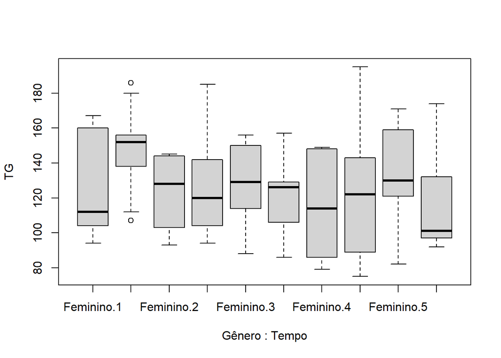

```r
boxplot(TG ~ Gênero:Tempo, dadosl)
```

### 3.4.2 Verificando a normalidade por grupo:

Lembrando que os pressupostos do *Teste de Shapiro-Wilk* são:

- H<sub>0</sub>: Distribuição dos dados = normal → p > 0,05
- H<sub>1</sub>: Distribuição dos dados ≠ normal → p ≤ 0,05

Nesse caso, verificamos que apenas os grupos `Masculino` e `Feminino`, analisados no `Tempo` 3, apresentam distribuição normal, com `p-value > 0.05`.

```r
dadosl %>% group_by(Gênero, Tempo) %>%
  shapiro_test(TG)
```

```
## # A tibble: 10 x 5
##    Gênero    Tempo variable statistic        p
##    <fct>     <fct> <chr>        <dbl>    <dbl>
##  1 Feminino  1     TG           0.830 0.00199
##  2 Feminino  2     TG           0.842 0.00310
##  3 Feminino  3     TG           0.912 0.0592
##  4 Feminino  4     TG           0.872 0.0103
##  5 Feminino  5     TG           0.898 0.0325
##  6 Masculino 1     TG           0.908 0.0205
##  7 Masculino 2     TG           0.874 0.00357
##  8 Masculino 3     TG           0.939 0.115
##  9 Masculino 4     TG           0.910 0.0224
## 10 Masculino 5     TG           0.818 0.000281
```

### 3.4.3 Verificando a homogeneidade de variâncias:

Os pressupostos do *Teste de Levene* são:

- H<sub>0</sub>: As variâncias dos grupos são homogêneas → p > 0,05
- H<sub>1</sub>: As variâncias dos grupos **não** são homogêneas → p ≤ 0,05

```r
leveneTest(TG ~ Gênero, dadosl)
```

```
## Levene's Test for Homogeneity of Variance (center = median)
##        Df F value Pr(>F)
## group   1  2.2871 0.1318
##       238
```

Nesse caso, verificamos que o pressuposto de homogeneidade foi atendido, considerando que `p-value > 0.05`.

Analisando as premissas, verificamos que os dados não são válidos para seguir com teste paramétrico, então uma sugestão talvez seja transformar os dados porque não existe um teste não-paramétrico correspondente à ANOVA mista. Uma maneira de transformar os dados pode ser logaritmizando a variável dependente `TG`, e fazer o teste com `lnTG`.

Outra alternativa seria partirmos para outro modelo, que não assuma a normalidade como pressuposto - como o caso dos modelos lineares generalizados. Nesses modelos, a gente consegue dizer qual é a distribuição dos dados, sem atender aos quesitos de normalidade.

## 3.5 Passo 5: Construção do modelo da ANOVA mista (pacote: `ez`)

```r
mod.ANOVA <- ezANOVA(data = dadosl,
                     dv = .(TG),
                     wid = .(ID),
                     within = .(Tempo),
                     between = .(Gênero),
                     detailed = TRUE,
                     type = 3)
```

Os argumentos utilizados pela função `ezANOVA` correspondem a:

1. `dv` = variável dependente
2. `wid` = variável de identificação do sujeito
3. `within` = variável independente de medidas repetidas
4. `between` = variável independente entre sujeitos
5. `between_covariates` = covariável
6. `type` = tipo da soma dos quadrados (default é o tipo II, tipo III é o padrão no SPSS)

## 3.6 Passo 5: Analisando os resultados do modelo

```r
options(scipen = 999) # comando que transforma a notação científica dos valores
mod.ANOVA
```

```
## $ANOVA
##         Effect DFn DFd          SSn       SSd           F
## 1  (Intercept)   1  46 3749854.5482  32189.31 5358.713382
## 2       Gênero   1  46     243.0482  32189.31    0.347327
## 3        Tempo   4 184    8903.0798 135062.50    3.032238
## 4 Gênero:Tempo   4 184    9048.5798 135062.50    3.081793
##                                                          p p<.05         ges
## 1 0.000000000000000000000000000000000000000000000000288163     * 0.957302204
## 2 0.558513694336003174711891006154473870992660522460937500       0.001451079
## 3 0.018827474276161399596718482030155428219586610794067383     * 0.050541202
## 4 0.017380108067374572949903566154716827441006898880004883     * 0.051324786
##
## $`Mauchly's Test for Sphericity`
##         Effect         W            p p<.05
## 3        Tempo 0.4899731 0.0002278443     *
## 4 Gênero:Tempo 0.4899731 0.0002278443     *
##
## $`Sphericity Corrections`
##         Effect      GGe      p[GG] p[GG]<.05      HFe      p[HF] p[HF]<.05
## 3        Tempo 0.818585 0.02731489         * 0.888775 0.02363903         *
## 4 Gênero:Tempo 0.818585 0.02551874         * 0.888775 0.02198214         *
```

Sabemos que Esfericidade é a condição em que as variâncias das diferenças entre todas as combinações de grupos são iguais. No teste da ANOVA mista, verificamos que tem o aporte do teste de esfericidade e, quando ocorre de a hipótese nula ser rejeitada, a ANOVA mista efetua correção de *Green-Geisser (GG)* e de *Huynh-Feldt (HFe)*.

Os pressupostos da esfericidade são:

- H<sub>0</sub>: os dados são esféricos → p > 0,05
- H<sub>1</sub>: os dados **não** são esféricos → p ≤ 0,05

Verificamos, então, que o teste rejeita a hipótese nula (H<sub>0</sub>) para esfericidade, o que nos permite considerar a correção de *Green-Geisser* e de *Huynh-Feldt* para a variável *Tempo* e interação *Gênero:Tempo*. Como a variável *Gênero* é intersujeito, analisamos apenas pela homogeneidade e, como vimos anteriormente, o teste não rejeitou a hipótese nula.

As premissas da ANOVA mista são:

Verificamos pelo resultado do teste que `p-value < 0.05` para `Tempo` e a interação `Gênero:Tempo` corrigidas por *GG* e *HFe*, que há efeito sobre `TG`, mas não há efeito da variável `Gênero`, pois `p-value > 0.05`.

Sempre que temos a interação das variáveis independentes com efeito significativo sobre a variável dependente no modelo, a melhor maneira de entendermos o comportamento é através do gráfico, como podemos ver na sequência.

## 3.7 Passo 6: Visualização das diferenças

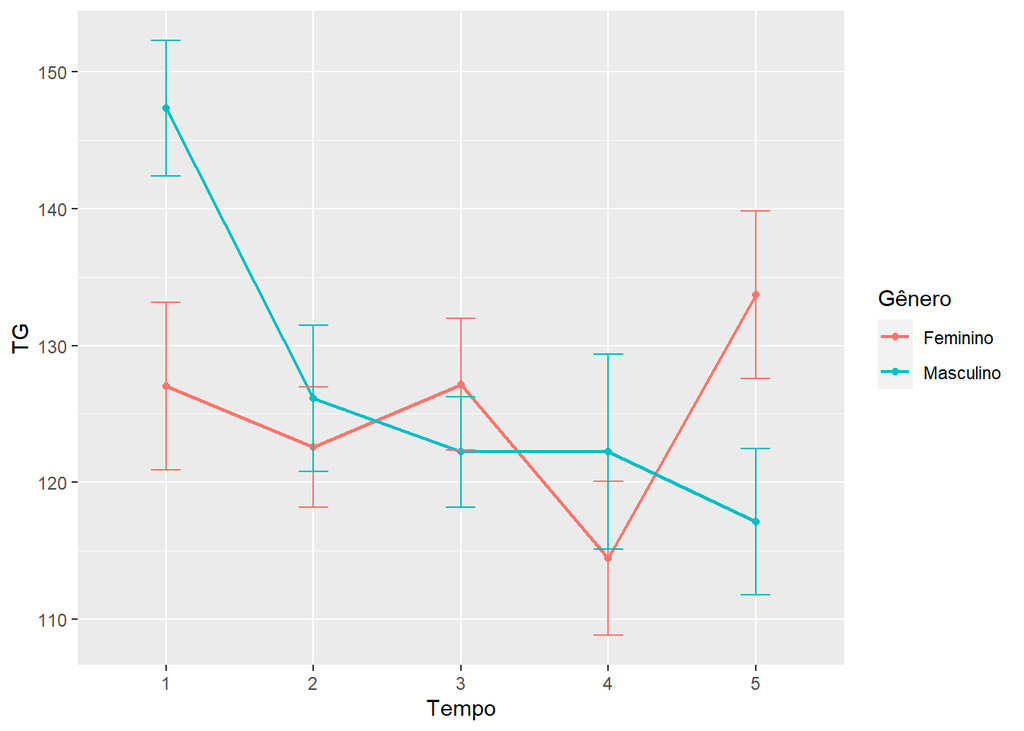

```r
ggplot(dadosl, aes(x = Tempo, y = TG, group = Gênero, color = Gênero)) +
  geom_line(stat = "summary", fun.data = "mean_se", size = 0.8) +
  geom_point(stat = "summary", fun = "mean") +
  geom_errorbar(stat = "summary", fun.data = "mean_se", width = 0.2)
```

Pelo gráfico podemos observar que houve uma mudança significativa nos triglicérides para o `Gênero Masculino` ao longo do tempo, enquanto que para o `Gênero Feminino`, o efeito parece ter se estabilizado nos cinco períodos. Para entender melhor isso, faremos os testes de *post-hoc* a fim de observar os efeitos caso a caso.

## 3.8 Passo 7: Comparações entre partes (Testes de *post-hoc*)

Primeiro efetuaremos o agrupamento entre gêneros a fim de comparar tempo a tempo, e depois agruparemos com tempo e comparar os dois gêneros.

```r
CompTempo <- dadosl %>% group_by(Gênero) %>%
  emmeans_test(TG ~ Tempo, p.adjust.method = "bonf")

tabela3_CompTempo <- datatable(CompTempo, options = list(pageLength = 10))
tabela3_CompTempo
```

|  | Gênero | term | .y. | group1 | group2 | df | statistic | p | p.adj | p.adj.signif |
| --- | --- | --- | --- | --- | --- | --- | --- | --- | --- | --- |
| 1 | Feminino | Tempo | TG | 1 | 2 | 230 | 0.532153360199727 | 0.595133451965139 | 1 | ns |
| 2 | Feminino | Tempo | TG | 1 | 3 | 230 | -0.0171662374258005 | 0.986318878596205 | 1 | ns |
| 3 | Feminino | Tempo | TG | 1 | 4 | 230 | 1.51062889347017 | 0.132255654237131 | 1 | ns |
| 4 | Feminino | Tempo | TG | 1 | 5 | 230 | -0.806813159012482 | 0.420607637761909 | 1 | ns |
| 5 | Feminino | Tempo | TG | 2 | 3 | 230 | -0.549319597625526 | 0.58331907498812 | 1 | ns |
| 6 | Feminino | Tempo | TG | 2 | 4 | 230 | 0.97847553327045 | 0.328867248669235 | 1 | ns |
| 7 | Feminino | Tempo | TG | 2 | 5 | 230 | -1.33896651921221 | 0.181903396805335 | 1 | ns |
| 8 | Feminino | Tempo | TG | 3 | 4 | 230 | 1.52779513089597 | 0.127937452948637 | 1 | ns |
| 9 | Feminino | Tempo | TG | 3 | 5 | 230 | -0.789646921586681 | 0.430547304231124 | 1 | ns |
| 10 | Feminino | Tempo | TG | 4 | 5 | 230 | -2.31744205248266 | 0.0213586374099076 | 0.213586374099076 | ns |

[output cut: 10 more lines]

```r
CompGen <- dadosl %>% group_by(Tempo) %>%
  emmeans_test(TG ~ Gênero, p.adjust.method = "bonferroni")

tabela4_CompGen <- datatable(CompGen, options = list(pageLength = 10))
tabela4_CompGen
```

|  | Tempo | term | .y. | group1 | group2 | df | statistic | p | p.adj | p.adj.signif |
| --- | --- | --- | --- | --- | --- | --- | --- | --- | --- | --- |
| 1 | 1 | Gênero | TG | Feminino | Masculino | 230 | -2.59154047727968 | 0.0101661217295266 | 0.0101661217295266 | * |
| 2 | 2 | Gênero | TG | Feminino | Masculino | 230 | -0.451142487457743 | 0.652311913000423 | 0.652311913000423 | ns |
| 3 | 3 | Gênero | TG | Feminino | Masculino | 230 | 0.627148749380729 | 0.531183794810858 | 0.531183794810858 | ns |
| 4 | 4 | Gênero | TG | Feminino | Masculino | 230 | -0.993322696599778 | 0.321596587207928 | 0.321596587207928 | ns |
| 5 | 5 | Gênero | TG | Feminino | Masculino | 230 | 2.11612126403946 | 0.0354094739931087 | 0.0354094739931087 | * |

Observamos, dessa forma, com os dados agrupados por `Tempo`, que temos significância estatística dentro do momento 1, comparando `Feminino` e `Masculino`, assim como dentro do momento 5.

## 3.9 Passo 8 (opcional): Análise descritiva dos dados (pacote: `rstatix`)

```r
dadosl %>% group_by(Tempo, Gênero) %>%
  get_summary_stats(TG, type = "mean_sd")
```

```
## # A tibble: 10 x 6
##    Gênero    Tempo variable     n  mean    sd
##    <fct>     <fct> <fct>    <dbl> <dbl> <dbl>
##  1 Feminino  1     TG          21  127   28.1
##  2 Masculino 1     TG          27  147.  25.8
##  3 Feminino  2     TG          21  123.  20.2
##  4 Masculino 2     TG          27  126.  27.8
##  5 Feminino  3     TG          21  127.  22.1
##  6 Masculino 3     TG          27  122.  21.0
##  7 Feminino  4     TG          21  114.  25.8
##  8 Masculino 4     TG          27  122.  37.0
##  9 Feminino  5     TG          21  134.  28.1
## 10 Masculino 5     TG          27  117.  27.7
```

# 4 Resultado

A ANOVA mista mostrou que há efeito do tempo [F(4,184) = 3,032; p = 0,027] interação entre o tempo e o gênero [F(4,184) = 3,082; p = 0,025]. As comparações entre pares subsequentes mostraram que não houve alteração nas concentrações de triglicerídeos no gênero feminino ao longo do tempo. Para o gênero masculino, houve uma queda das concentrações de triglicerídeos do primeiro para o segundo tempo analisados, e essas concentrações seguiram baixando nos tempos seguintes.